# Demographic Patterns of Melanoma: Comparing Incidence and Survival Among Black and White Populations

Violette Bonvallet, Andre Gala-Garza, Lynle Hayes

2025-12-12

### Abstract

Melanoma incidence has increased substantially in the United States over recent decades, with pronounced disparities by race, sex, and anatomical site. Using Surveillance, Epidemiology, and End Results (SEER) data from 1975–2022, we examined trends in melanoma incidence and survival among Black and White populations. Log-linear regression and joinpoint regression were used to characterize incidence patterns over time by race, sex, and subsite while survival and Cox proportional hazards models evaluated disparities in mortality while accounting for competing risks. Incidence increased steadily overall which was mainly driven by White populations and males with minimal change among Black individuals. Trunk melanoma exhibited the highest incidence and early annual percent increases while leg melanoma showed distinct patterns among Black patients. Survival analyses revealed higher cumulative melanoma mortality among Black patients in men, but these disparities were substantially decreased after adjusting for stage and other covariates. Together, these findings suggest that observed survival disparities are largely explained by differences in stage at diagnosis rather than actual differences in prognosis which demonstrates the importance of earlier detection and targeted public health messaging for underserved populations.

### Introduction

Melanoma is the most aggressive form of skin cancer, arising from melanocytes in the epidermis. Its incidence has increased sharply in recent decades, especially among fair-skinned populations who face higher susceptibility to ultraviolet (UV) radiation (Culp et al., 2019). Major risk factors include intermittent or intense UV exposure, a history of blistering sunburns, numerous or atypical nevi, older age, male sex, indoor tanning, immunosuppression, and genetic mutations such as *CDKN2A* and *BRAF* (Culp et al., 2019). Although early detection has improved outcomes, incidence continues to rise without a proportional decline in mortality.

Substantial racial disparities exist in the burden and outcomes of melanoma in the United States. Non-Hispanic White adults have the highest incidence, while melanoma remains rare among Black individuals, approximately 1 in 38 for White individuals versus 1 in 1,000 for Black individuals (Culp et al., 2019). However, Black patients are far more likely to be diagnosed at later stages and experience poorer survival. Recent qualitative research shows that many Black adults do not perceive themselves at risk, are unfamiliar with melanoma, and rarely encounter public health messages that depict skin cancer on darker skin (de Vere Hunt et al., 2023). These communication gaps are especially concerning because the predominant melanoma subtype in Black populations, acral lentiginous melanoma, occurs on the palms, soles, and nails, areas not traditionally a focus for sun prevention campaigns.

The Surveillance, Epidemiology, and End Results (SEER) program provides comprehensive, population-based cancer data essential for evaluating these disparities (National Cancer Institute, 2025). Melanoma cases are identified using ICD-O-3 histology codes 8720–8799 and primary site codes C44.0–C44.7, which allow systematic analysis of anatomical patterns and demographic trends (Zabor et al., 2021). In our research, primary sites are categorized as head and neck, trunk, arms, and legs.

### Methods

For this project, a variety of regression methods were used on a series of SEER data. These methods include joinpoint regression, log-linear regression, and survival regression analysis, which were conducted in three separate investigations.

**Log-Linear Regression:** The log-linear regression investigation serves as exploratory data analysis before we fit the regression models. Melanoma incidence data obtained from the SEER database was loaded from a CSV file into RStudio. The CSV file contains melanoma skin cancer incidence cases in the United States from the years 1975 to 2022. The analysis was of period trends of the following demographics: race (Black, White), sex (male, female), and anatomical location (“Head and Neck”, “Trunk”, “Arm (shoulder to finger)”, “Leg (hip to toe)”), which we refer to as a “subsite” in this report. An additional variable was created that adjusts the count to account for the age of participants: Count_adj = round(Rate * Population), where Rate is the incidence rate. Using this information, line plots were created using the ggplot2 library to visualize the average yearly age-adjusted melanoma incidence (per 100,000 cases) in the United states from 1975 to 2022. These plots showed the difference in melanoma incidence rates across different demographics, including sex, race, and subsite.

**Joinpoint Regression:** For the joinpoint regression investigation, joinpoint-style segmented log-linear trends were fit to the data with a Poisson generalized linear model and offset by the log of Population. This provided log-linear models with annual percent changes (APC) as the slope of their segments. Using the function selgmented() from the R package “segmented”, the best fit segments were identified on the log scale, with a set max of 5 joinpoints. Furthermore, the same model was automatically fit multiple times across many different strata, for each combination of race, sex, and subsite. Notably, due to the computational challenge of repeatedly fitting joinpoint regression models, the futureverse package “furrr” was used to parallelize the process of fitting models, which makes it significantly faster to do so.

The annual percent change (APC) and average annual percent change (AAPC) were also computed from the segment slopes. These calculations and statistics were compiled into tables, along with line plots of the demographics fitted individually and in combinations.

**Survival Regression:** For the survival regression investigation, the variables from the SEER data were recoded into factors such as age groups, race, sex, subsite, and year of diagnosis, as well as the stage of the cancer and event type as a competing risks outcome with 3 states: “Cancer death”, “Other death”, and “Alive”. The survfit() package from the survival library was utilized to get state occupation probabilities over time, to find the probability that a person is alive at time ‘t’ or the cumulative incidence that they have died by cancer or other means at that time. This workflow is repeated to plot the fraction of deaths from cancer over time, stratified by sex, race, age group, stage, and subsite. The follow-up is administratively censored at 5 years (t = 5) by setting the event to “Alive” automatically if t > 5. Finally, Cox proportional hazards models were computed for each covariate in three different model types: univariable, bivariable (with stage), and multivariable (all covariates).

### Results

**Log-Linear Regression:**

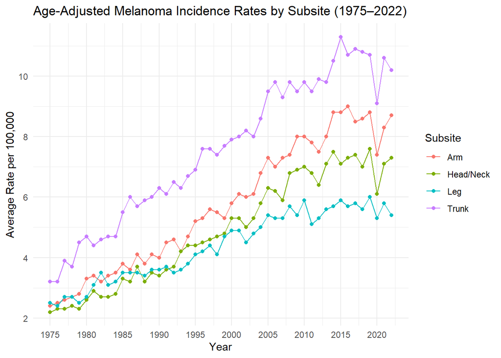

**Figure 1:** The age-adjusted average yearly incidence rates of melanoma in the United states from 1975 to 2022, plotted by subsite.

When analyzing the sex and race plots, the marginal trends are very comparable to joint trends. White women and men have the highest age-adjusted rate. Black males and females are both at an incidence rate that is around 0.5 per 100,000 people; there does not appear to be a significant difference among the sexes for Black individuals.

**Joinpoint Regression:**

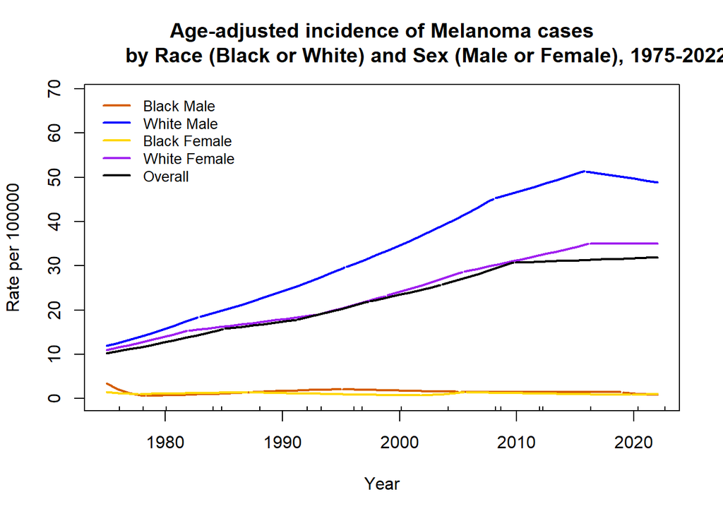

**Figure 2:** The age-adjusted average yearly incidence rates of melanoma in the United states from 1975 to 2022, plotted by both race (Black/White) and sex (male/female).

For combined stratifications, for Race * Sex, White men have the highest APC followed by White women. For Sex (Men) * Site, there are high early APCs across sites with Trunk being the highest, Head/Neck being unusually low, and Leg remaining the lowest. For Sex (Women) * Site, the trunk, arm, and leg trends appear to converge, while head/neck stays low. For Black * Site, black incidence is 3-6 times higher on the leg than other sites. Finally, there is consistently a lower or negative APC in the last two 5-year periods and visible dips around the year 2020.

**Survival Regression:**

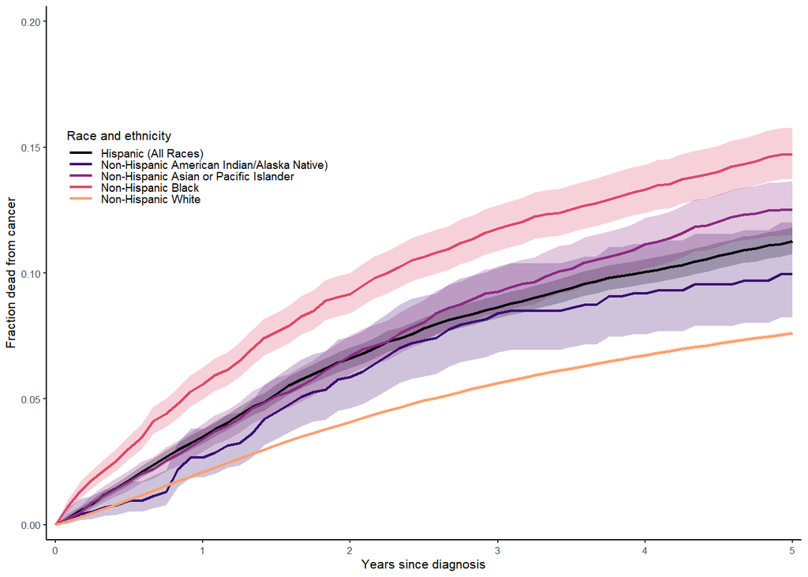

**Figure 3:** Stratified cumulative incidence plot showing the fractions of the data cohort who died from melanoma, separated by race and ethnicity.

For the Cox models after adjustment, for the >=70 age group, the hazard ratio (HR) dropped from 3.27 (crude) to 1.53 (full), suggesting strong confounding by other factors. Similarly, for Black race, HR dropped from 2.07 to 1.18, and for the head/neck subsite, HR dropped from 1.62 to 1.00. The full table of HRs and p-values across the model types can be seen in our GitHub repository.

### Conclusion

This study demonstrates that melanoma incidence in the United States has risen significantly since the mid-1970s, with increases concentrated among White individuals and males, while incidence among Black individuals has remained low and relatively stable. Joinpoint analyses indicate that the incidence has increased more slowly after approximately 2010 which suggests that there have been recent changes in detection practices or population risk. Despite their lower incidence, Black patients experience disproportionately worse melanoma outcomes which are reflected by their higher cumulative cancer mortality. However, survival regression results show that much of this disparity is explained by later stage at diagnosis and other clinical factors since the hazard ratios for Black race and head/neck subsites tend towards the null after adjustment. These findings highlight that melanoma disparities are driven less by biological differences and more by inequities in early detection and diagnosis. Public health efforts should therefore prioritize culturally inclusive education and improved access to timely dermatologic care to reduce preventable mortality targeting this particular population.

### References

- Culp, M. B., & Lunsford, N. B. (2019). *Melanoma among non-Hispanic Black Americans.* Preventing Chronic Disease, 16, 180640. https://doi.org/10.5888/pcd16.180640
- de Vere Hunt, I., Owen, S., Amuzie, A., Nava, V., Tomz, A., Barnes, L., Robinson, J. K., Lester, J., Swetter, S., & Linos, E. (2023). Qualitative exploration of melanoma awareness in Black people in the USA. *BMJ Open,* 13(1), e066967.
- Department of Health. (2007). *World class commissioning: Adding life to years and years to life.* London: Department of Health Commissioning. www.dh.gov.uk/prod_consum_dh/idcplg?IdcService=GET_FILE&dID=155367&Rendition=Web
- National Cancer Institute. (2025). *Surveillance, Epidemiology, and End Results (SEER) Program.* U.S. Department of Health and Human Services, National Institutes of Health. https://seer.cancer.gov
- National Institute for Health Research. (2008). *Transforming health research: The first two years. Progress report 2006–2008.* London: NIHR. http://www.nihr.ac.uk/files/pdfs/NIHR%20Progress%20Report%202006-2008.pdf
- Zabor, E. C., Styperek, A., Christos, P. J., & Hale, C. S. (2021). Melanoma epidemiology and ICD-O-3 coding considerations for cancer surveillance. *Journal of the National Cancer Institute.*

### Supplementary Information

**Group Member Contributions:** * **Violette Bonvallet:** Contributed to background analysis; Wrote report conclusion * **Andre Gala-Garza:** Initiated and maintained the GitHub repository; Reformatted code for style and efficiency; Wrote Methods and Results sections of report * **Lynle Hayes:** Designed the initial project proposal; Created initial code base; Wrote report introducton

**GitHub Repository:** The GitHub repository for this project is available at this link:

https://github.com/AndreGalaGarza/melanomaBD

The R markdown source code for this report document can be found at the base directory as “biostat_625_final_project.Rmd”, along with HTML and PDF knitted versions. The source code for each type of regression conducted for this project can be found in the “regression” folder, along with the data used for the project and HTML and PDF knitted versions of each Quarto markdown file.